# QK Box 12.4

Skrip et al (2016) studied the effects of dietary antioxidants and exercise on the allocation of nutrients to eggs in zebra finches (*Taeniopygia guttata*). We will focus on one aspect of their study, how the order of egg laying affected the mass of the eggs. Mating pairs of finches were allocated randomly to two diet groups (supplemented with high antioxidant food, no supplement) and two exercise groups (additional flight exercise, no additional exercise). The finches laid between one and nine eggs but few laid more than five and pairs that laid only one egg don’t provide enough information for fitting a regression between order and egg mass. So we will analyze egg mass as the response variable from pairs that laid between two and five eggs. The between-subjects component was a two factor (diet and exercise) crossed design with pairs as subjects, and egg order (within each pair) was the within-subjects factor.

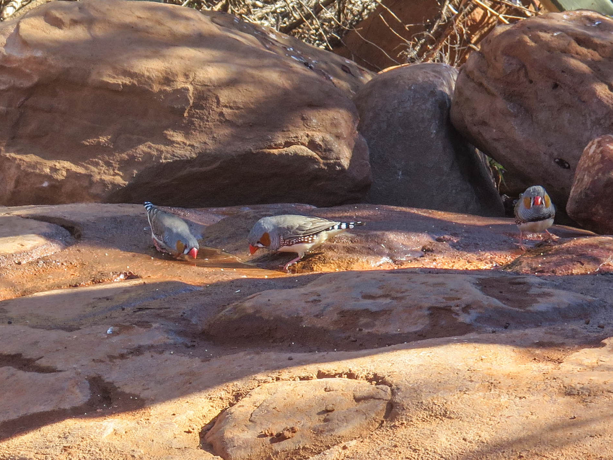

Link to [paper](http://doi.org/10.1242/jeb.137802)

### Preliminaries

First, load the required packages (afex, car, lattice, lme4, lmerTest, nlme, VCA, ez, emmeans, Rmisc, MuMIn)

Import skrip data file

```r
skrip <- read.csv("../data/skrip.csv")
skrip
```

| date | pair | female | male | order | diet | exercise | group | wmass | yolkmass | albmass | yolkperc | lutein | vite |
| --- | --- | --- | --- | --- | --- | --- | --- | --- | --- | --- | --- | --- | --- |
| 1/9/2012 | a | 521 | 507 | 1 | con | none | con_none | 1.1126 | 0.3517 | 0.5652 | 31.6106 | 104.68736 | 235.47994 |
| 1/9/2012 | a | 521 | 507 | 2 | con | none | con_none | 1.0873 | 0.3415 | 0.5902 | 31.4081 | 82.78190 | 201.79324 |
| 2/9/2012 | a | 521 | 507 | 3 | con | none | con_none | NA | 0.3596 | 0.5209 | NA | 65.15896 | 128.22844 |
| 3/9/2012 | a | 521 | 507 | 4 | con | none | con_none | 1.0710 | 0.3671 | 0.4784 | 34.2764 | 57.25066 | 128.60217 |
| 10/9/2012 | b | 535 | 517 | 1 | con | none | con_none | 1.0301 | 0.3049 | 0.4198 | 29.5991 | 85.66036 | 126.91617 |
| 11/9/2012 | b | 535 | 517 | 2 | con | none | con_none | NA | NA | NA | NA | NA | NA |
| 12/9/2012 | b | 535 | 517 | 3 | con | none | con_none | 0.9662 | 0.3047 | 0.4986 | 31.5359 | 62.58182 | 84.15000 |
| 13/9/2012 | b | 535 | 517 | 4 | con | none | con_none | 1.0453 | 0.3134 | 0.6056 | 29.9818 | 49.09371 | 68.78140 |
| 14/9/2012 | b | 535 | 517 | 5 | con | none | con_none | 1.0587 | 0.3130 | 0.5685 | 29.5646 | 41.94054 | 64.64200 |
| 31/10/2012 | c | 536 | 503 | 1 | con | none | con_none | 0.9553 | 0.2848 | 0.5363 | 29.8126 | 146.36114 | 168.19533 |

[output cut: 72 more lines]

set contrasts using afex

```r
set_sum_contrasts()
```

```
## setting contr.sum globally: options(contrasts=c('contr.sum', 'contr.poly'))
```

### Diagnostics

check individual regressions

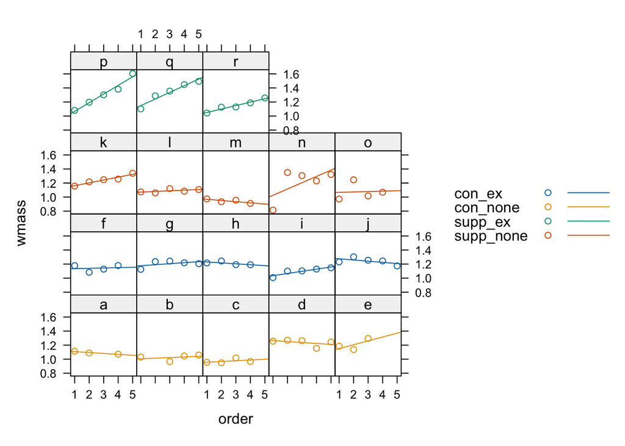

```r
xyplot(wmass~order|pair, groups=group, type=c("p","r"), auto.key=T, skrip)
```

```r
list_skrip <- lmList(wmass~order|pair, skrip, na.action=na.omit)
summary(list_skrip)
```

```
## Call:
##   Model: wmass ~ order | pair
##    Data: skrip
##
## Coefficients:
##    (Intercept)
##    Estimate Std. Error  t value     Pr(>|t|)
## a 1.1207500 0.08654913 12.94929 1.308318e-16
## b 0.9963171 0.08530375 11.67964 4.502662e-15
## c 0.9457000 0.08654913 10.92674 4.047996e-14
## d 1.2784300 0.07411624 17.24899 3.364372e-21
## e 1.0951667 0.10794573 10.14553 4.270621e-13
## f 1.1296500 0.08654913 13.05212 9.910952e-17
## g 1.1619600 0.07411624 15.67753 1.265078e-19
## h 1.2429500 0.08654913 14.36121 3.233641e-18
## i 1.0043300 0.07411624 13.55074 2.626501e-17
## j 1.2924600 0.07411624 17.43828 2.209927e-21
## k 1.1215000 0.07411624 15.13164 4.738873e-19
## l 1.0617000 0.07411624 14.32480 3.546833e-18
## m 0.9854500 0.08654913 11.38602 1.051081e-14
## n 0.9360900 0.07411624 12.63002 3.124596e-16
## o 1.0614000 0.08654913 12.26356 8.622791e-16
## p 0.9439400 0.07411624 12.73594 2.337511e-16
## q 1.0535300 0.07411624 14.21456 4.696690e-18
## r 1.0016300 0.07411624 13.51431 2.891131e-17
##    order
##       Estimate Std. Error    t value     Pr(>|t|)
## a -0.013050000 0.03271249 -0.3989301 6.918743e-01
## b  0.008848571 0.02388983  0.3703907 7.128685e-01
## c  0.010560000 0.03160327  0.3341426 7.398594e-01
## d -0.013730000 0.02234689 -0.6144032 5.421131e-01
## e  0.055050000 0.04996916  1.1016795 2.765911e-01
## f  0.004920000 0.03160327  0.1556801 8.769972e-01
## g  0.014480000 0.02234689  0.6479649 5.203747e-01
## h -0.013040000 0.03160327 -0.4126155 6.818920e-01
## i  0.030930000 0.02234689  1.3840853 1.733130e-01
## j -0.017040000 0.02234689 -0.7625223 4.498170e-01
## k  0.040600000 0.02234689  1.8168078 7.606196e-02
## l  0.009220000 0.02234689  0.4125854 6.819139e-01
## m -0.016890000 0.03160327 -0.5344383 5.957287e-01
## n  0.089510000 0.02234689  4.0054794 2.349747e-04
## o  0.005820000 0.03160327  0.1841581 8.547355e-01
## p  0.123080000 0.02234689  5.5077020 1.775475e-06
## q  0.094630000 0.02234689  4.2345941 1.148112e-04
## r  0.049090000 0.02234689  2.1967264 3.335257e-02
##
## Residual standard error: 0.07066707 on 44 degrees of freedom
```

some evidence of different slopes

### First model with random slopes and intercepts

```r
skrip1.lmer <- lmer(wmass~diet*exercise*order+(order|pair), REML=FALSE, skrip, na.action=na.omit)
```

### Second just random intercepts

```r
skrip2.lmer <- lmer(wmass~diet*exercise*order+(1|pair), REML=FALSE, skrip, na.action=na.omit)
```

### Test random slopes term

```r
rand(skrip1.lmer)
```

|  | npar | logLik | AIC | LRT | Df | Pr(>Chisq) |
| --- | --- | --- | --- | --- | --- | --- |
|  | 12 | 81.19122 | -138.3824 | NA | NA | NA |
| order in (order \| pair) | 10 | 79.83148 | -139.6630 | 2.719476 | 2 | 0.256728 |

```r
anova(skrip2.lmer,skrip1.lmer)
```

|  | npar | AIC | BIC | logLik | deviance | Chisq | Df | Pr(>Chisq) |
| --- | --- | --- | --- | --- | --- | --- | --- | --- |
| skrip2.lmer | 10 | -139.6630 | -115.8427 | 79.83148 | -159.6630 | NA | NA | NA |
| skrip1.lmer | 12 | -138.3824 | -109.7981 | 81.19122 | -162.3824 | 2.719476 | 2 | 0.256728 |

```r
AICc(skrip2.lmer,skrip1.lmer)
```

|  | df | AICc |
| --- | --- | --- |
| skrip2.lmer | 10 | -136.4746 |
| skrip1.lmer | 12 | -133.7257 |

No strong evidence for random slopes so use random intercepts.

### Refit model with REML

```r
skrip3.lmer <- lmer(wmass~diet*exercise*order+(1|pair), REML=TRUE, skrip, na.action=na.omit)
```

Check residual plot - OK

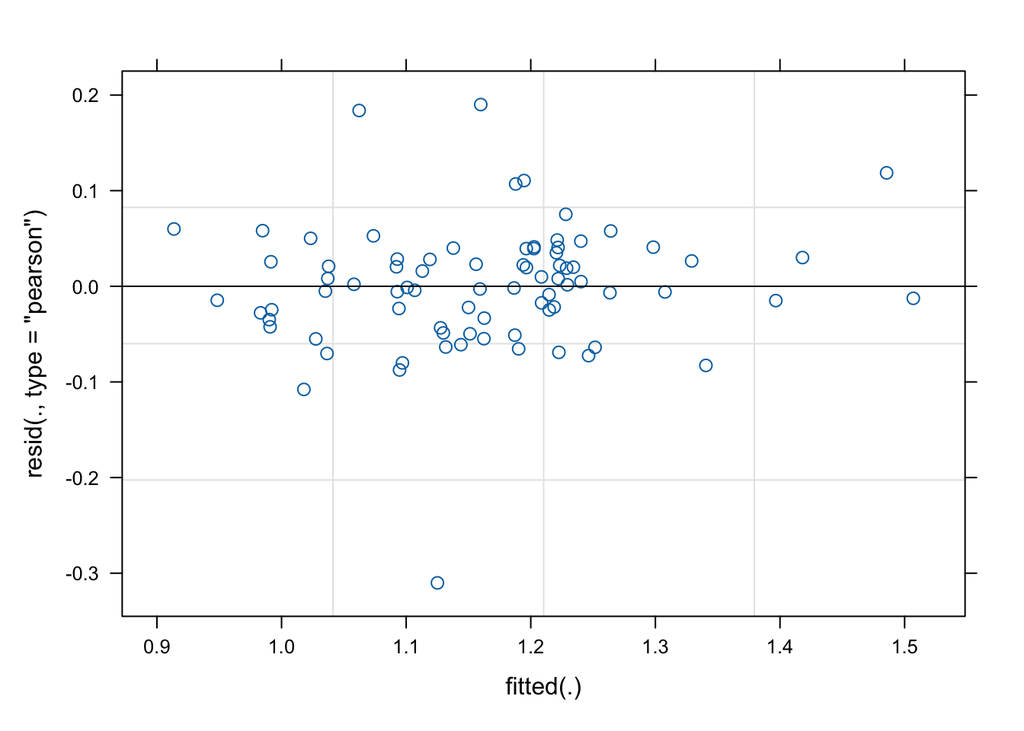

```r
plot(skrip3.lmer)
```

```r
summary(skrip3.lmer, ddf="Kenward-Roger")
```

```
## Linear mixed model fit by REML. t-tests use Kenward-Roger's method [
## lmerModLmerTest]
## Formula: wmass ~ diet * exercise * order + (1 | pair)
##    Data: skrip
##
## REML criterion at convergence: -103.2
##
## Scaled residuals:
##     Min      1Q  Median      3Q     Max
## -4.1386 -0.4493  0.0028  0.4177  2.5362
##
## Random effects:
##  Groups   Name        Variance Std.Dev.
##  pair     (Intercept) 0.008465 0.09200
##  Residual             0.005614 0.07493
## Number of obs: 80, groups:  pair, 18
##
## Fixed effects:
##                        Estimate Std. Error        df t value Pr(>|t|)
## (Intercept)            1.070290   0.029803 31.437992  35.912  < 2e-16 ***
## diet1                  0.062936   0.029803 31.437992   2.112   0.0428 *
## exercise1              0.010650   0.029803 31.437992   0.357   0.7232
## order                  0.032613   0.006371 58.803754   5.119 3.55e-06 ***
## diet1:exercise1        0.018304   0.029803 31.437992   0.614   0.5435
## diet1:order           -0.029235   0.006371 58.803754  -4.589 2.39e-05 ***
## exercise1:order        0.014902   0.006371 58.803754   2.339   0.0228 *
## diet1:exercise1:order -0.012184   0.006371 58.803754  -1.913   0.0607 .
## ---
## Signif. codes:  0 '***' 0.001 '**' 0.01 '*' 0.05 '.' 0.1 ' ' 1
##
## Correlation of Fixed Effects:
##             (Intr) diet1  exrcs1 order  dt1:x1 dt1:rd exrc1:
## diet1       -0.115
## exercise1    0.115 -0.145
## order       -0.600  0.028 -0.028
## diet1:xrcs1 -0.145  0.115 -0.115  0.084
## diet1:order  0.028 -0.600  0.084 -0.009 -0.028
## exercs1:rdr -0.028  0.084 -0.600  0.009  0.028 -0.137
## dt1:xrcs1:r  0.084 -0.028  0.028 -0.137 -0.600  0.009 -0.009
```

```r
anova(skrip3.lmer, ddf="Kenward-Roger")
```

|  | Sum Sq | Mean Sq | NumDF | DenDF | F value | Pr(>F) |
| --- | --- | --- | --- | --- | --- | --- |
| diet | 0.0250369494 | 0.0250369494 | 1 | 31.43799 | 4.4593627 | 4.275445e-02 |
| exercise | 0.0007168968 | 0.0007168968 | 1 | 31.43799 | 0.1276874 | 7.232297e-01 |
| order | 0.1471332194 | 0.1471332194 | 1 | 58.80375 | 26.2060838 | 3.547621e-06 |
| diet:exercise | 0.0021177036 | 0.0021177036 | 1 | 31.43799 | 0.3771869 | 5.435319e-01 |
| diet:order | 0.1182304258 | 0.1182304258 | 1 | 58.80375 | 21.0581706 | 2.388993e-05 |
| exercise:order | 0.0307179741 | 0.0307179741 | 1 | 58.80375 | 5.4712172 | 2.275004e-02 |
| diet:exercise:order | 0.0205364106 | 0.0205364106 | 1 | 58.80375 | 3.6577661 | 6.068293e-02 |

Get var comps with CIs

```r
skrip3.ci <- confint.merMod(skrip3.lmer, oldNames=FALSE)
```

```
## Computing profile confidence intervals ...
```

```r
skrip3.vc <- (skrip3.ci)^2
print(skrip3.vc)
```

```
##                              2.5 %       97.5 %
## sd_(Intercept)|pair   2.952456e-03 1.455114e-02
## sigma                 3.768687e-03 7.636959e-03
## (Intercept)           1.031731e+00 1.265179e+00
## diet1                 7.192387e-05 1.381911e-02
## exercise1             1.924024e-03 4.250565e-03
## order                 4.169228e-04 2.016701e-03
## diet1:exercise1       1.318915e-03 5.293660e-03
## diet1:order           1.732100e-03 2.929702e-04
## exercise1:order       6.808788e-06 7.343093e-04
## diet1:exercise1:order 5.905052e-04 4.097410e-08
```

#### Draw line plot

```r
skrip_stats <- summarySE(skrip,measurevar='wmass', groupvars= c('group','order'), na.rm=TRUE)
skrip_stats
```

| group | order | N | wmass | sd | se | ci |
| --- | --- | --- | --- | --- | --- | --- |
| con_ex | 1 | 5 | 1.151200 | 0.09021738 | 0.04034644 | 0.11201967 |
| con_ex | 2 | 5 | 1.193100 | 0.09675505 | 0.04327017 | 0.12013726 |
| con_ex | 3 | 5 | 1.183620 | 0.06725212 | 0.03007606 | 0.08350453 |
| con_ex | 4 | 5 | 1.192360 | 0.04380529 | 0.01959032 | 0.05439145 |
| con_ex | 5 | 3 | 1.175700 | 0.02944130 | 0.01699794 | 0.07313624 |
| con_none | 1 | 5 | 1.107680 | 0.11946793 | 0.05342768 | 0.14833903 |
| con_none | 2 | 4 | 1.110350 | 0.13264329 | 0.06632165 | 0.21106508 |
| con_none | 3 | 4 | 1.135175 | 0.16754899 | 0.08377449 | 0.26660782 |
| con_none | 4 | 4 | 1.059350 | 0.07662769 | 0.03831385 | 0.12193176 |
| con_none | 5 | 2 | 1.151850 | 0.13173399 | 0.09315000 | 1.18358297 |

[output cut: 10 more lines]

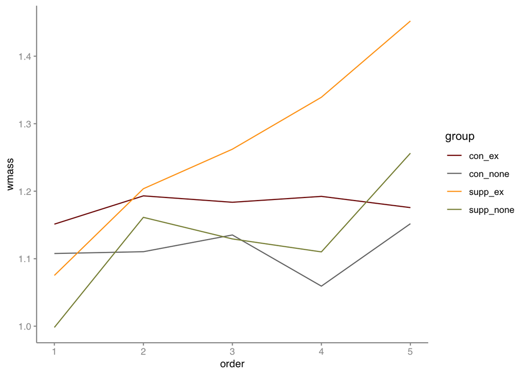

```r
ggplot(skrip_stats, aes(x=order, y=wmass, fill=group, colour=group))+
  geom_line()+
  theme_qk()+
  scale_colour_uchicago()
```